```python
import pandas as pd
import numpy as np
import matplotlib.pyplot as plt
import seaborn as sns
```

# Analysis of Spotify Data

In this notebook I'll analyse a spotify dataset with the following properties:

- 114000 datapoints
- 21 columns

The dataset is available on Kaggle: [Spotify Tracks Dataset | MaharshiPandya](https://www.kaggle.com/datasets/maharshipandya/-spotify-tracks-dataset)

For the target variable I will use the `popularity` variable. Below you can see an overview of the structure of the data.

Spotify defines [Audio Features](https://developer.spotify.com/documentation/web-api/reference/get-audio-features) for each track, these are numbers that specify characteristics about the track. For eaxmple, the `Instrumentalness` metric is a predictor of how likely the track is to contain vocal content.

### Data Exploration Plan

1. Inspect the data size and data types
2. Inspect basic data quality
   - Missing values
   - Value ranges
   - Mapping categorical or numerical values
   - Visualisation
   - Encoding categorical values
3. Hypothesis formulation
4. Hypothesis Testing
5. Conclusion

# 1. Inspect data size and data types

```python
data = pd.read_csv("dataset.csv")
data.info()
```

```
<class 'pandas.core.frame.DataFrame'>
RangeIndex: 114000 entries, 0 to 113999
Data columns (total 21 columns):
 #   Column            Non-Null Count   Dtype
---  ------            --------------   -----
 0   Unnamed: 0        114000 non-null  int64
 1   track_id          114000 non-null  object
 2   artists           113999 non-null  object
 3   album_name        113999 non-null  object
 4   track_name        113999 non-null  object
 5   popularity        114000 non-null  int64
 6   duration_ms       114000 non-null  int64
 7   explicit          114000 non-null  bool
 8   danceability      114000 non-null  float64
 9   energy            114000 non-null  float64
 10  key               114000 non-null  int64
 11  loudness          114000 non-null  float64
 12  mode              114000 non-null  int64
 13  speechiness       114000 non-null  float64
 14  acousticness      114000 non-null  float64
 15  instrumentalness  114000 non-null  float64
 16  liveness          114000 non-null  float64
 17  valence           114000 non-null  float64
 18  tempo             114000 non-null  float64
 19  time_signature    114000 non-null  int64
 20  track_genre       114000 non-null  object
dtypes: bool(1), float64(9), int64(6), object(5)
memory usage: 17.5+ MB
```

# 2. Inspect basic data quality

First we'll have to check if there are any inconsistencies in the data and if columns need to be transformed. Let's first check the `object` type columns for number of unique values

```python
data.select_dtypes(include='object').nunique()
```

```
track_id       89741
artists        31437
album_name     46589
track_name     73608
track_genre      114
dtype: int64
```

Since there are so many values it will not be useful to on-hot encode these columns, apart from the genre column.

Next, let's check for null-values

```python
data.isna().sum()
```

```
Unnamed: 0          0
track_id            0
artists             1
album_name          1
track_name          1
popularity          0
duration_ms         0
explicit            0
danceability        0
energy              0
key                 0
loudness            0
mode                0
speechiness         0
acousticness        0
instrumentalness    0
liveness            0
valence             0
tempo               0
time_signature      0
track_genre         0
dtype: int64
```

```python
np.where(data.isna())
data.loc[65900]
```

```
Unnamed: 0                           65900
track_id            1kR4gIb7nGxHPI3D2ifs59
artists                                NaN
album_name                             NaN
track_name                             NaN
popularity                               0
duration_ms                              0
explicit                             False
danceability                         0.501
energy                               0.583
key                                      7
loudness                             -9.46
mode                                     0
speechiness                         0.0605
acousticness                          0.69
instrumentalness                   0.00396
liveness                            0.0747
valence                              0.734
tempo                              138.391
time_signature                           4
track_genre                          k-pop
Name: 65900, dtype: object
```

There is only one row where null values occur, and it is a single k-pop track. It is likely that something has gone wrong in the parsing of the name of the artist, track and album. Since it is only a single entry, we can safely remove it. However, it may be interesting to look at other k-pop tracks to see if they got parsed correctly.

```python
data[data['track_genre']=='k-pop'].sample(5)
```

|  | Unnamed: 0 | track_id | artists | album_name | track_name | popularity | duration_ms | explicit | danceability | energy | ... | loudness | mode | speechiness | acousticness | instrumentalness | liveness | valence | tempo | time_signature | track_genre |
| --- | --- | --- | --- | --- | --- | --- | --- | --- | --- | --- | --- | --- | --- | --- | --- | --- | --- | --- | --- | --- | --- |
| 65594 | 65594 | 7mQjVfocpzkKd3PN1TtwKR | Vijay Antony;Jayadev;Rajalakshmi | Dishyum (Original Background Score) | Nenjangootil Neeye | 49 | 275626 | False | 0.672 | 0.711 | ... | -8.798 | 0 | 0.2060 | 0.1980 | 0.000000 | 0.1020 | 0.791 | 180.037 | 4 | k-pop |
| 65653 | 65653 | 3thIARBf9vzQXQYuaOf8Wd | Jubin Nautiyal;Rocky - Shiv | Chitthi | Chitthi | 47 | 229912 | False | 0.729 | 0.520 | ... | -6.586 | 0 | 0.0258 | 0.5620 | 0.000893 | 0.1010 | 0.458 | 114.973 | 4 | k-pop |
| 65734 | 65734 | 2Ygw4CPjg1lg4zxTITYY2V | BTS | Proof | DNA | 63 | 223441 | False | 0.595 | 0.754 | ... | -4.527 | 0 | 0.0554 | 0.0245 | 0.000000 | 0.0726 | 0.672 | 129.951 | 4 | k-pop |
| 65739 | 65739 | 6EfGUQtLk3xVc64tk8ihTL | Ilaiyaraaja | Muthal Mariyathai (Original Motion Picture Sou... | Hey Kiliyirukku | 46 | 68205 | False | 0.803 | 0.572 | ... | -9.308 | 1 | 0.2050 | 0.8110 | 0.003380 | 0.0962 | 0.790 | 112.478 | 3 | k-pop |
| 65502 | 65502 | 2e3cJdJ8xWwydl8JIYlCqB | WayV | Love Talk (English Version) | Love Talk - English Version | 69 | 232150 | False | 0.751 | 0.719 | ... | -5.198 | 0 | 0.0373 | 0.1420 | 0.000000 | 0.1480 | 0.437 | 98.010 | 4 | k-pop |

5 rows × 21 columns

Rerunning the cell above gives a sample of 5 k-pop tracks. It looks like most of them have been translated, with some korean script still available. For now it seems like there are no more issues with this data.

A lot of the variables are numeric, so we can check their basic distribution to start seeing some patterns. Especially the `Audio Features` are interesting. So let's take a look at the following columns: ["popularity", "danceability", "energy", "speechiness", "acousticness", "instrumentalness", "liveness", "valence"].

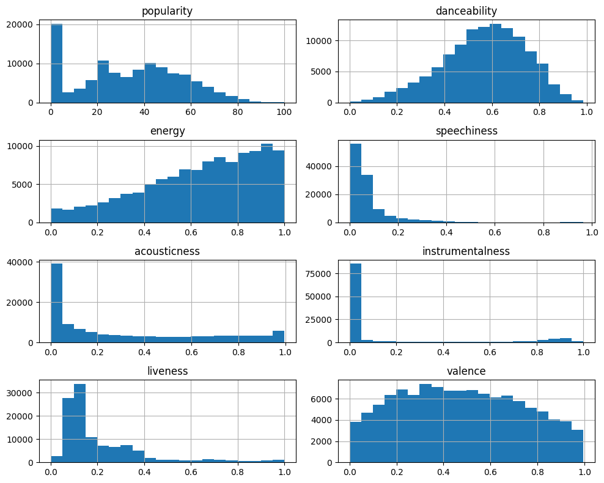

```python
audio_feature_cols = ["popularity", "danceability", "energy", "speechiness", "acousticness", "instrumentalness", "liveness", "valence"]
data[audio_feature_cols].hist(figsize=(10, 8), bins=20, layout=(4, 2))
plt.tight_layout()
```

This already gives a lot of insight into how the tracks are distributed. For example, most tracks will have low speechiness, acousticness, instrumentalness and liveness. Which means that most tracks will be studio produced tracks that include sung vocals.

We can also explore the more objective measures of the data in the same way. These are: ["duration_ms", "explicit", "key", "loudness", "tempo", "time_signature", "track_genre"]

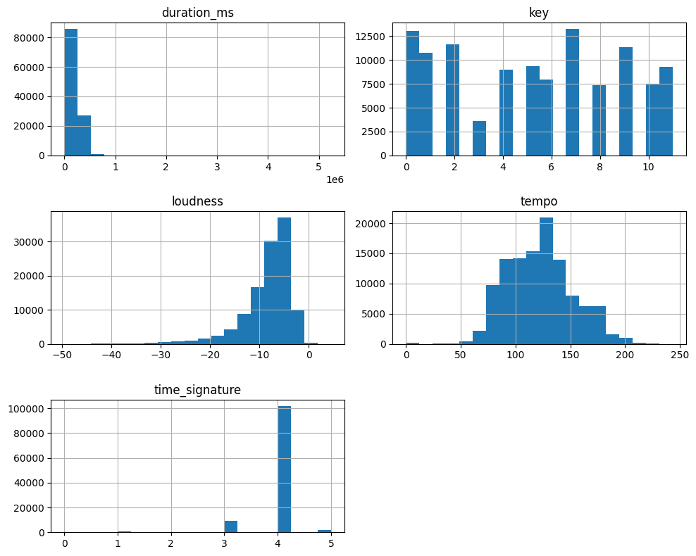

```python
audio_property_cols = ["duration_ms", "explicit", "key", "loudness", "tempo", "time_signature", "track_genre"]
data[audio_property_cols].hist(figsize=(10, 8), bins=20, layout=(3, 2))
plt.tight_layout()
```

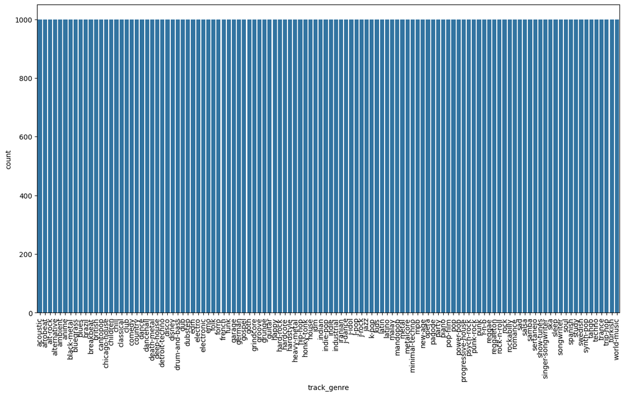

```python
plt.figure(figsize=(15, 8))
sns.countplot(data=data, x="track_genre")
plt.xticks(rotation=90);
```

From this we can see that the genre is distributed evenly across all categories. So we can safely compare metrics across different genres since we won't have to account for underrepresented data when comparing between genres.

So let's also use one-hot encoding to represent the genres:

```python
cols_before = len(data.columns)
num_genres = data['track_genre'].nunique()
dummies = pd.get_dummies(data=data['track_genre'], prefix='track_genre')
data = pd.concat([data, dummies], axis=1)
cols_after = len(data.columns)
f"Before: {cols_before}, After: {cols_before}+{num_genres}={cols_after}"
```

```
'Before: 21, After: 21+114=135'
```

# 3. Hypothesis formulation

I am interested in finding if any of the Audio Features impact the popularity of a track. So for my first hypothesis I want to check:

### Do Audio Features Impact Track Popularity

For each of the audio features look at:

**H_0** => The Audio Feature does not impact track popularity.  
**H_A** => The Audio Feature *does* impact track popularity.

For this I will look at the correlation between each audio feature and popularity. First I will look at direct linear correlation, then use a Linear Regression model to capture more complex relationships.

The second hypothesis I want to check is whether genre has impact on popularity:

### Does Genre Impact Track Popularity

**H_0** => Genre does not impact track popularity.  
**H_A** => Genre *does* impact track popularity.

Finally, I want to know if any of the objective measures (like key, tempo and length) have an effect on popularity.

### Do Music Properties Like Key and Tempo Impact Track Popularity

**H_0** => Music Properties do not impact track popularity.  
**H_A** => Music Properties *do* impact track popularity.

# 4. Hypothesis Testing

## Do Audio Feature Impact Track Popularity

First, let's see if any simple linear correlations are present.

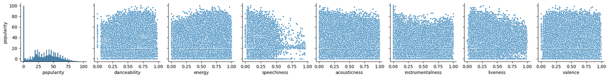

```python
sns.pairplot(data=data, x_vars=audio_feature_cols, y_vars=['popularity'], markers='.')
```

Hmm, quite messy and not very insightful. Let's take a measurement of the correlation values between each of the Audio Features and popularity.

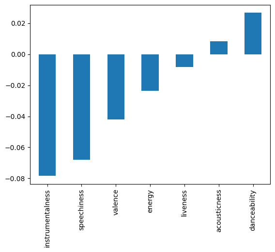

```python
import statsmodels.api as sm
corr = data[audio_feature_cols].corr(method='spearman')["popularity"].drop('popularity')
corr.sort_values().plot.bar()
```

```python
X = data[audio_feature_cols].drop('popularity', axis=1)
y = data['popularity']

X = sm.add_constant(X)
model = sm.OLS(y, X).fit()
model.summary()
```

OLS Regression Results

| Dep. Variable: | popularity | R-squared: | 0.022 |
| --- | --- | --- | --- |
| Model: | OLS | Adj. R-squared: | 0.022 |
| Method: | Least Squares | F-statistic: | 364.7 |
| Date: | Tue, 25 Nov 2025 | Prob (F-statistic): | 0.00 |
| Time: | 17:41:31 | Log-Likelihood: | -5.1445e+05 |
| No. Observations: | 114000 | AIC: | 1.029e+06 |
| Df Residuals: | 113992 | BIC: | 1.029e+06 |
| Df Model: | 7 |  |  |
| Covariance Type: | nonrobust |  |  |

|  | coef | std err | t | P>\|t\| | [0.025 | 0.975] |
| --- | --- | --- | --- | --- | --- | --- |
| const | 35.6648 | 0.418 | 85.400 | 0.000 | 34.846 | 36.483 |
| danceability | 9.2878 | 0.447 | 20.791 | 0.000 | 8.412 | 10.163 |
| energy | -0.7862 | 0.420 | -1.874 | 0.061 | -1.608 | 0.036 |
| speechiness | -12.7612 | 0.650 | -19.644 | 0.000 | -14.034 | -11.488 |
| acousticness | -1.2614 | 0.304 | -4.150 | 0.000 | -1.857 | -0.666 |
| instrumentalness | -8.8238 | 0.225 | -39.152 | 0.000 | -9.266 | -8.382 |
| liveness | 1.1891 | 0.365 | 3.257 | 0.001 | 0.474 | 1.905 |
| valence | -9.6735 | 0.311 | -31.122 | 0.000 | -10.283 | -9.064 |

| Omnibus: | 12758.730 | Durbin-Watson: | 0.568 |
| --- | --- | --- | --- |
| Prob(Omnibus): | 0.000 | Jarque-Bera (JB): | 3496.773 |
| Skew: | -0.015 | Prob(JB): | 0.00 |
| Kurtosis: | 2.143 | Cond. No. | 16.0 |

Notes:  
[1] Standard Errors assume that the covariance matrix of the errors is correctly specified.

From this we can already see that R^2 is only 0.022, so the model can only explain 2.2% of the effect using these features. The large sample size does make that the model is significant with almost all p-values < 0.05. Only energy has no significant effect on popularity. From this analysis it is hard to generalize to a conclusion, however, we can take a look at the coefficients of the model to see how strongly the Audio Features impact the popularity.

For example, with speechiness, the coefficient being -12.76, when speechiness increases, the popularity will go down propertionally. When speechiness increases by 0.1, popularity will (on average) go down by ~1.2 points. So however significant the effect may be, it is definitely not a strong effect.

- The strongest effects seem to be danceability (positive) and speechiness (negative), instrumentalness (negative) and valence (negative).
- Liveness, acousticness have much smaller effects on popularity.
- Energy has no significant effect on popularity.

These features are not capable of determining the variability of popularity on their own. But possibly interactions between them could do this. Another option is that none of these features properly capture the popularity of a track. These might just be the wrong features to use, and other non-music related features might be more important.

A next step might also be to check for effects corrected by the genre category. It is conceivable that some Audio Features have more impact in specific genres.

## Does Genre Impact Track Popularity

Another simple test we can do is see if genre has any impact on popularity. Let's first check if there is any effect overall by using a one-way ANOVA.

```python
import scipy.stats as stats

# First, group by genre, then unpack into (genre_name, genre_data)
# For each grouped genre dataframe we just grab the popularity column
# Then take the values to get it into the correct format for the ANOVA
genre_groups = [
    genre['popularity'].values for _, genre in data.groupby('track_genre')
]

f, p = stats.f_oneway(*genre_groups)
print(f"F = {f:.3f}, p = {p:.3e}")
```

```
F = 343.462, p = 0.000e+00
```

From this we can see that, with a high f-value and a p < 0.05, the effect of genre overall on popularity is significant. Let's dive in a bit deeper to see where this significance lies.

```python
import statsmodels.formula.api as smf

model = smf.ols('popularity ~ C(track_genre)', data=data).fit()
```

```python
model.summary().tables[0]
```

OLS Regression Results

| Dep. Variable: | popularity | R-squared: | 0.254 |
| --- | --- | --- | --- |
| Model: | OLS | Adj. R-squared: | 0.253 |
| Method: | Least Squares | F-statistic: | 343.5 |
| Date: | Tue, 25 Nov 2025 | Prob (F-statistic): | 0.00 |
| Time: | 17:41:33 | Log-Likelihood: | -4.9899e+05 |
| No. Observations: | 114000 | AIC: | 9.982e+05 |
| Df Residuals: | 113886 | BIC: | 9.993e+05 |
| Df Model: | 113 |  |  |
| Covariance Type: | nonrobust |  |  |

That is already a much stronger effect than the Audio Features from before. Now, with an R^2 of 0.254 (or 25%) there is more explainabilty in this model. We also retrieve a similar F-stat and probability from the simple ANOVA earlier. So our conclusions hold; There is an effect of genre on popularity. Let's visualise the results to see where this effect lies.

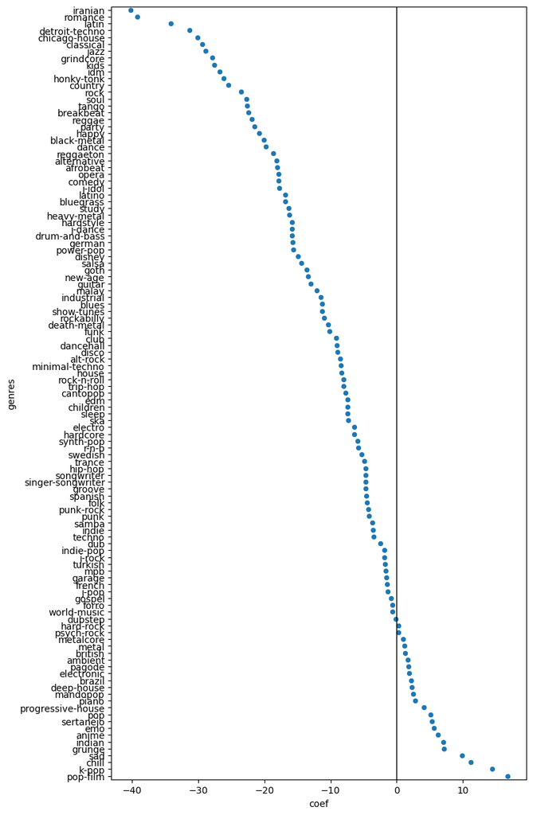

```python
coefs = model.params

plot_data = coefs.to_frame('coef').sort_values('coef')
plot_data.index = plot_data.index.str.extract(r'\[T\.(.*)\]')[0].to_list()
plot_data = plot_data.reset_index().rename(columns={'index': 'genres'})

plt.figure(figsize=(8, 15))
sns.pointplot(data=plot_data, x='coef', y='genres', linestyle='none', markers='.')
plt.axvline(0, color="black", lw=1);
```

The top 5 strongest effects are:

**Positive effect on popularity**:

- pop-film
- k-pop
- chill
- sad
- grunge

**Negative effect on popularity**:

- iranian
- romance
- latin
- detroit-techno
- chicago-house

## Do Music Properties Like Key and Tempo Impact Track Popularity

The musical properties under consideration are: ["duration_ms", "key", "loudness", "tempo", "time_signature"]. Again, we first look visually if there are any obvious correlations.

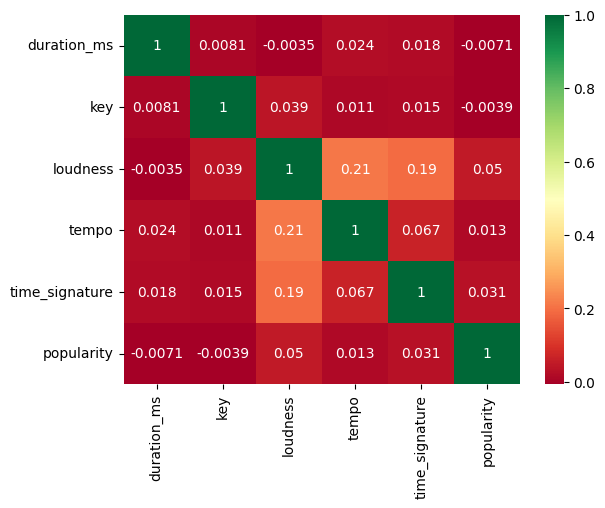

```python
feature_cols = ["duration_ms", "key", "loudness", "tempo", "time_signature"]
corr = data[feature_cols + ['popularity']].corr()
sns.heatmap(corr, annot=True, cmap="RdYlGn")
```

Hmmm, no correlations present. But what about using some feature engineering to see if there are higher order effects or maybe combined effects. Let's check for the following:

- Polynomial features
- Multiplicative features (interaction features)

### Polynomial features and interaction features

For this we can simply use `PolynomialFeatures` from scikit-learn.

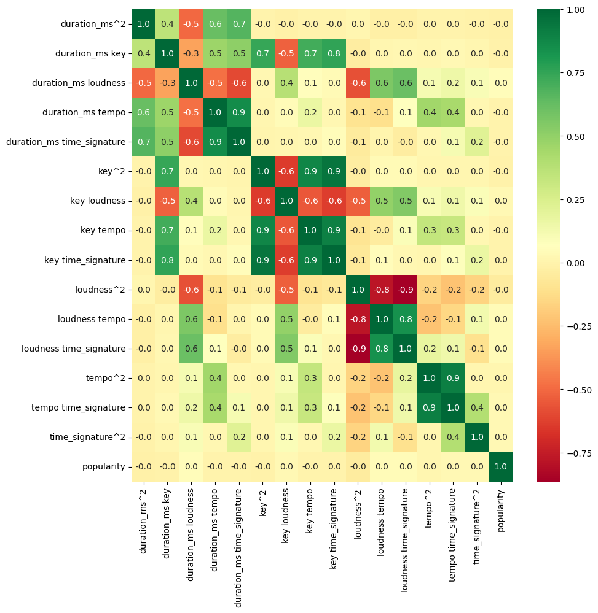

```python
from sklearn.preprocessing import PolynomialFeatures

pf = PolynomialFeatures(degree=2)
pf.fit(data[feature_cols])
feat_cols = pf.get_feature_names_out(input_features=feature_cols)
feat_array = pf.transform(data[feature_cols])
feat_poly = pd.DataFrame(feat_array, columns=feat_cols).drop(columns=feature_cols+["1"])

feat_poly['popularity'] = data['popularity']

plt.figure(figsize=(10, 10))
sns.heatmap(feat_poly.corr(), annot=True, fmt='.1f', cmap="RdYlGn")
```

There are actually some strong correlations between some of the combined features. But nothing for the popularity, to illustrate explicitly:

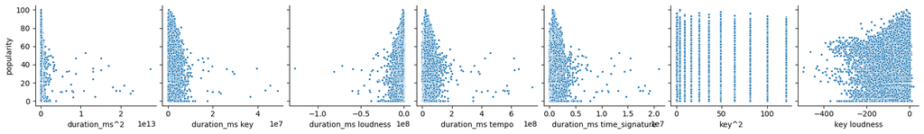

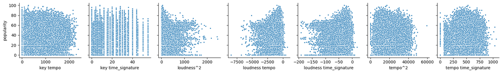

```python
sns.pairplot(data=feat_poly, x_vars=feat_poly.columns[0:7], y_vars=['popularity'], markers='.')
sns.pairplot(data=feat_poly, x_vars=feat_poly.columns[7:-2], y_vars=['popularity'], markers='.')
```

So for this hypothesis we can accept our null hypothesis that there is no significant effect of musical properties on popularity. Even combined features show no effect on this pair of features/target.

# 5. Conclusions

When considering this dataset with evenly distributed tracks across genres, we observe that genre has a strong effect on popularity. More esotheric measures such as the Audio Features seem to have only a minor effect (though an additional analysis using interaction features might be interesting). Finally, there is no effect on popularity from technical musical properties such as key, tempo and length.

This is to be expected from a platform like spotify, where people are generally not concerned with the technical details of the music they listen to, but more in the general feel of the music (Audio Features) or only in the type of genre.